# PG2: Análisis, descriptivo y probabilistico, de problemas de acoso sexual en la UTEC en los últimos 5 años

05 Mayo, 2023

[figure not shown]

# 1 **Estudio**

## 1.1 Introducción

- Según el Comercio, siete de cada diez universidades del Perú, reportaron casos de hostigamiento y acoso sexual. La Superintendencia Nacional de Educación Superior (SUNEDU) informó que se han registrado denuncias en 32 universidades públicas y en 34 privadas durante el periodo 2020, asimismo, la SUNEDU ha sancionó a la Universidad Nacional Enrique Guzmán y Valle (UNEGV) y a la Universidad Andina Néstor Cáceres Velásquez (UANCV), por no haber determinado la responsabilidad en las denuncias efectuas en sus instituciones correspondientes. En este sentido, el grupo de trabajo busca explorar esta situación para poder reflejar si la comunidad Utecina sufre o ha sufrido algún tipo de acoso, ha sido testigo de algún hecho referente a acoso, y por último evaluar la opinión de los estudiantes sobre el acoso sexual.

## 1.2 Relevancia

- La problemática del acoso sexual ha aumentado con gran magnitud en los últimos años, generando zozobra entre la población femenina y masculina de nuestro país, en este sentido, el grupo de trabajo investigará esta situación que también involucra a los estudiantes de la comunidad universitaria de UTEC.
- Para ello, la investigación busca evaluar a los encuestados en relación con su opinión, involucramiento en temas de acoso u hostigamiento sexual, hayan sufrido o estén sufriendo los encuestados en el momento de la encuesta, como por ejemplo, cuándo ocurrió, cuántas veces, denuncia del hecho, año de ocurrencia, medios de acoso y la frecuencia que esto ocurre en esta parte de la población, entre otras variables a exponer.
- Por otro lado, la iniciativa del estudio busca conocer las estadísticas del grupo de encuestados pertenecientes a la universidad y que puedan expresar su experiencia. De igual forma, la población encuestada tiene la posibilidad de compartir su capacidad de reacción ante un hecho de acoso sexual y cómo tomaría acción ante este tipo de hechos. Para finalizar, se aplicarán relaciones entre las variables con la finalidad de entenderlas ante las problemáticas y percepción de los encuestados en relación al acoso y hostigamiento sexual.

## 1.3 Objetivos

### 1.3.1 **Objetivo Principal**

- Poner en contexto al lector del presente informe sobre los casos de acoso sexual entre los estudiantes de pre grado de primer a noveno ciclo que se encuentran cursando el año académico 2022-2.

### 1.3.2 **Objetivo Secundario**

- Explorar, de forma cuantitativa, los casos de acoso en la Universidad.
- Medir la probabilidad de acoso entre la población encuestada de UTEC.

# 2 **Parámetros**

## 2.1 **Procedimiento**

Para obtener estos datos, se hizo uso de la herramienta de Google Forms, la cual fue compartida a través de todos los grupos universitarios y estudiantes de UTEC, ya sea por Telegram o WhatsApp. La encuesta empleada representa una muestra representativa de muestreo aleatorio simple; debido a que, el total de encuestados forman parte de la comunidad de estudiantes de UTEC. Dentro de esta población de muestreo se refleja el comportamiento y propiedades que tienen los estudiantes que han experimentado algún caso de acoso dentro o fuera de la universidad, testigo de algún hecho y la reacción ante ello. Asimismo, la opinión general de aquella población que no haya sufrido ningún tipo de acoso.

## 2.2 **Tipo de Muestreo**

El tipo de muestreo es un muestreo por conveniencia.

## 2.3 **Unidad Muestral**

La unidad muestral es el alumno encuestado.

## 2.4 **Tabla de variables**

| Variables | Tipo + Restricción |
| --- | --- |
| Género de sexo | Categórica nominal |
| Edad | Numérica discreta. Entero no negativo |
| Orientación sexual | Categórica nominal |
| Carrera | Categórica nominal |
| Ciclo | Numérica discreta. Entero no negativo |
| Laboralmente activo | Categórica nominal |
| Edad de acoso dUTEC | Numérica discreta. Entero no negativo |
| Modalidad del acoso dUTEC | Categórica nominal |
| Veces de acoso dUTEC | Numérica discreta. Entero no negativo |
| Denuncia | Categórica nominal |
| Edad de acoso fUTEC | Numérica discreta. Entero no negativo |
| Modalidad del acoso fUTEC | categórica nominal |
| Veces de acoso fUTEC | Numérica discreta. Entero no negativo |
| Denuncia | Categórica nominal |
| Veces como testigo | Numérica discreta. Entero no negativo |
| Reacción como testigo | Categórica nominal |

## 2.5 **Subida de datos**

Cargamos las librerías **dplyr**,**readr**, **ggmosaic**, **ggplot2**, **knitr**, **Rlab** y **datasets**.

Hemos obtenido más de 200 respuestas para la elaboración del estudio, cumpliendo así nuestro principal objetivo de tener un población significativa para poder estudiar la problemática planteada.

```r
nrow(UTEC) #Devuelve el número de filas de nuestra data. Cada fila representa una respuesta.
```

```
## [1] 239
```

## 2.6 **Limpieza de datos**

Función para redondear:

```r
r <- function(a){
  return(round(a,digits = 2))
}
```

**Creamos una variable para almacenar la data recopilada en las encuestas. Esto con la finalidad de poder trabajar de forma rápida y leer la base de datos de forma sencilla, se le designo la variable p1.**

**De igual forma, para poder trabajar con las columnas correspondiente a la información en el excel de la encuesta realizada para la investigación, la denominamos p2.**

Con la finalidad de poder agilizar el trabajo con la base de datos se genero un renombramiento de variables, como se consigna continuación: **Renombrar las variables:**

```r
names(p2)=c("Género","Edad","Orientación","Carrera","Ciclo","Trabaja","Edad_de_acoso_dUTEC","Modalidad_del_acoso_dUTEC","Veces_de_acoso_dUTEC","Denuncia_dUTEC","Edad_de_acoso_fUTEC","Modalidad_del_acoso_fUTEC","Veces_de_acoso_fUTEC", "Denuncia_fUTEC", "Veces_como_testigo", "Reacción_como_testigo")
```

# 3 **Análisis exploratorio**

La tolerancia para casos de acoso en la universidad debe ser nula. 1 caso de acoso, debidamente demostrado, es demasiado. Primero describiremos la variable edad, creemos que la edad es importante porque a una temprana edad estos casos de acoso pueden ser traumáticos.

## 3.1 Descriptores numéricos

### 3.1.1 Variable: Edad

**Descriptores de tendencia central:**

```
## [1] 18
```

Se encontró que la mayoría de los estudiantes universitarios de UTEC encuestados, tienen $18\text{ Años}$. Los encuestados son de relativamente una edad joven. Asimismo, probablemente hayan estudiantes encuestados de menos de 18 años, como de 17 años por ejemplo. Pero es muy poco probable que hayan encuestados de menores a estas edades ya que los alumnos entran a la universidad generalmente con un mínimo de edad de 17 años, o inclusive de 16 años de edad en casos no tan comunes.

**Descriptor de dispersión**

Ahora queremos saber la dispersión de la edad de la muestra. Esto es importante porque nos dice qué tan separados están nuestros datos. En este caso usaremos el rango como descriptor de dispersión.

```
## [1] 17 29
```

Podemos ver que nuestra muestra abarca estudiantes de 17 hasta 29 años. Esto nos ayuda a decir que esta muestra si parece representativa debido a que es razonable que en la universidad existan estudiantes dentro de ese rango.

**Descriptores Gráficos:**

El grupo considera que la variable edad es importante en este estudio. En este rango de edad las personas están en formación y los casos de acoso pueden tener efectos extremadamente duraderos.

Usaremos un boxplot para ver el rango y la mediana de la edad de los encuestados. Esto nos ayudará a confirmar, razonablemente, si la muestra recolectada es representativa a la población, que en este caso son los estudiantes de UTEC.

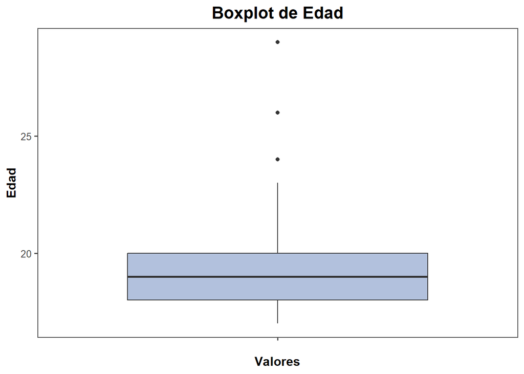

### 3.1.2 Variable: Acosado En la Universidad

La variable acosado en la universidad representa las personas que se han sentido acosados en la universidad por algún miembro de la comunidad. La Universidad debería ser un lugar seguro para todos los estudiantes. Este es un primer paso para entender la gravedad del problema de acoso sexual en la Universidad.

Creemos que el descriptor adecuado es la moda. Esto debido a que las respuestas son de carácter Binario. Si y No.

**Descriptores de posición:**

```
## [1] "No"
```

**Descriptor gráfico**

El Descriptor gráfico indicado para esta variable es el barplot. Con este descriptor podemos ver visualmente la proporción de personas que se sintieron acosadas dentro de la Universidad.

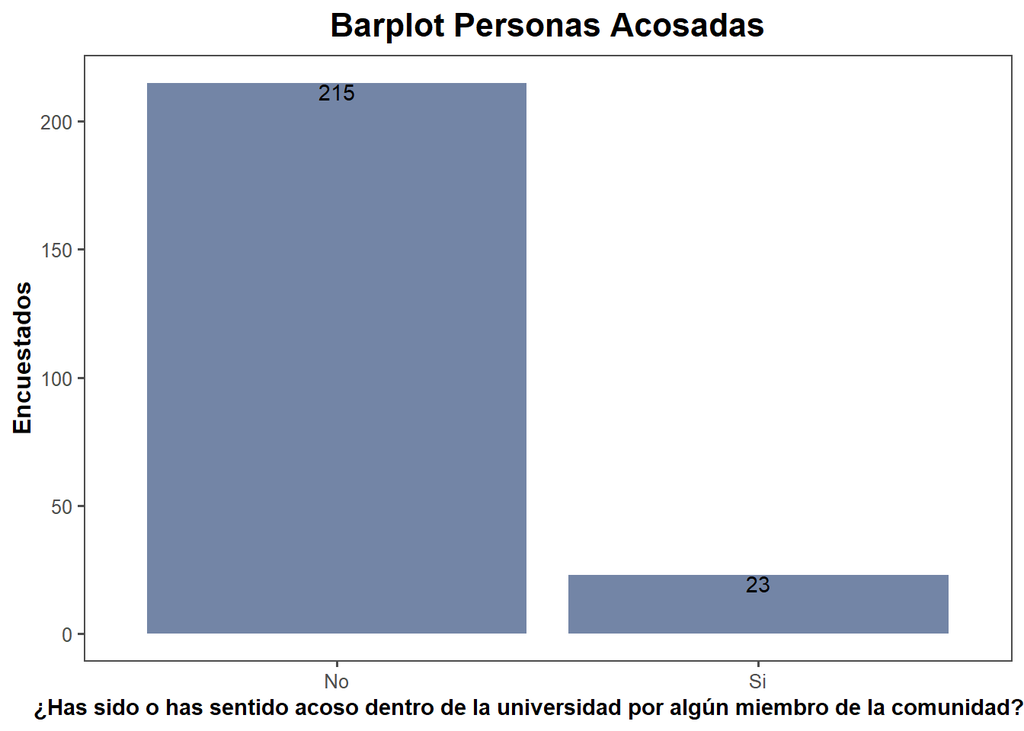

Esto es preocupante, casi el 10% de encuestados reportan algún sentir de acoso en la Universidad. A partir de ahora nos concentraremos en estos casos de acoso.

### 3.1.3 Variable: Año del acoso

**Descriptores de posición:**

El año en el que se realizó el acoso también es importante. Esto nos podrá ayudar a entender el medio por el cual el acoso se realiza. Como sabemos, durante los años 2020 y 2021 no hubieron clases presenciales en la universidad debido a la pandemia de COVID-19. Sin embargo, el acoso se pudo haber virtualizado. Para ver en qué año se reportaron más casos de acoso utilizaremos la moda.

```
## [1] 2022
```

El año en el que más sucedieron casos de acoso fue en el año $2022$. Para tomar en cuenta esta información veremos el promedio del ciclo de los encuestados. Esto servirá para entender que la mayoría de los encuestados son de ciclos menores al quinto, por lo que no estuvieron en la Universidad durante el 2019.

```
## [1] 3
```

Se encontró que la mayoría de los encuestados fueron de 3er ciclo, por lo que tuvieron que ingresar a la universidad a partir de 2020.

**Descriptor de dispersión**

```
## [1]  1 10
```

Si bien es cierto el rango de ciclo entre los encuestados es amplio, de hecho abarca todos los ciclos. Sin embargo, la mayoría de estudiantes encuestados recién están en $3er$ ciclo. Por lo tanto la **variable Año de acoso debería ser usada con precaución**.

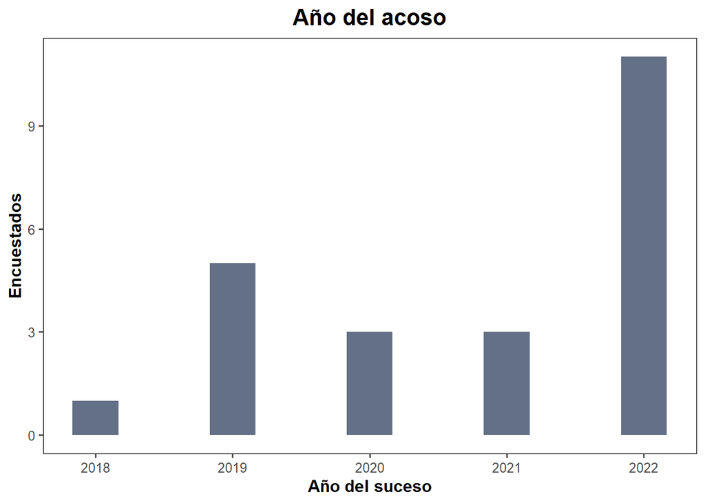

Esto no quiere decir necesariamente que existieron más casos de acoso en el 2022. Como vimos anteriormente, la mayoría de estudiantes encuestados están en tercer ciclo, es decir, no pueden haber sido víctimas de casos de acoso en años anteriores al 2021.

### 3.1.4 Variable: Exposición a comentarios machistas virtualmente.

Esta Variable fue obtenida a través de una pregunta, en la cual había que marcar del 0 al 100 qué tan expuestos están a comentarios machistas y/o acoso en las aplicaciones de mensajería de texto como WhatsApp.

De esta manera, 0 significaría que no sienten en ningún momento en las redes sociales exposición a comentarios machistas y/o acoso. Por otro lado, 100 significaría que siempre sienten que están leyendo o viendo stickers de machistas o de acoso.

Esta variable toma importancia debido a que, como podemos ver en la gráfica anterior, los casos de acoso sí ocurrieron durante los años de virtualidad como 2020 y 2021.

También es importante evaluar si existe una diferencia por sexo.

Es importante mencionar que esta pregunta puede ser subjetiva; sin embargo, puede describir sensaciones que pueden tener los estudiantes y merece ser evaluada.

**Descriptores de posición:**

Evaluaremos el promedio de la percepción de la exposición a comentarios machistas virtualmente.

```
## [1] 74.15546
```

En promedio, los estudiantes sienten que un $74.15%$ % de las veces que están en algún chat sienten que existe algo machista o de acoso.

Ahora evaluaremos cómo es este indicador pero en el otro ámbito, la presencialidad.

```
## [1] 67.26471
```

Ahora veremos si se puede ver una diferencia significativa clasificando por hombres y mujeres. En esta oportunidad nos concentraremos en la parte virtual, pues es la que presento un mayor promedio en la variable exposición a comentarios en vivo.

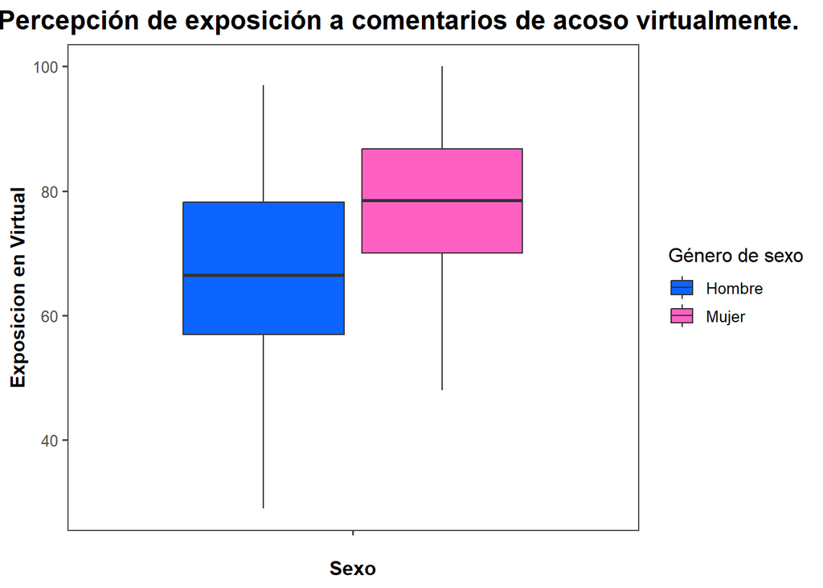

Como podemos observar en la gráfica, más mujeres expresan que se sienten más expuestas a comentarios machistas en comparación a los hombres. No podemos afirmar, estadísticamente, que existe una diferencia. Para eso necesitaríamos realizar una prueba de hipótesis. Ahora veremos la misma gráfica pero en la presencialidad.

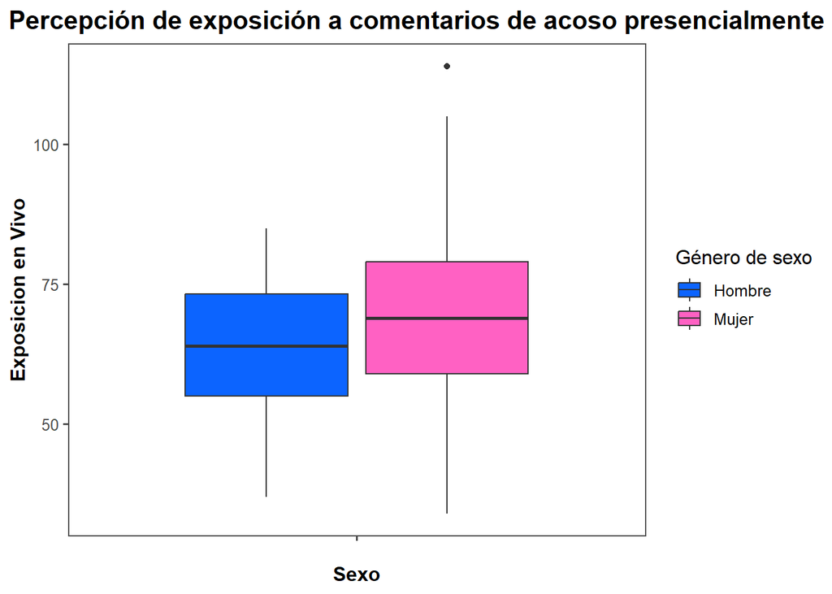

Como podemos observar en el boxplot, la mediana de las encuestadas es mayor a la de los encuestados. Sin embargo vemos que también existe mayor dispersión debido a que el rango es mayor.

Esto nos deja conclusiones interesantes debido a que, si bien es cierto no podemos demostrar, estadísticamente con los conocimientos que tenemos, que las mujeres se sienten más expuestas a comentarios machistas, si existe una diferencia entre la percepción de mujeres y hombres.

## 3.2 Variable Aleatoria

Para extrapolar modelos de nuestras variables haremos un primer análisis de la forma de los histogramas.

Una variable interesante que se preguntó fue, cada cuánto las personas perciben estos comentarios en el intervalo de una semana.

Variable: Frecuencia de comentarios machistas.

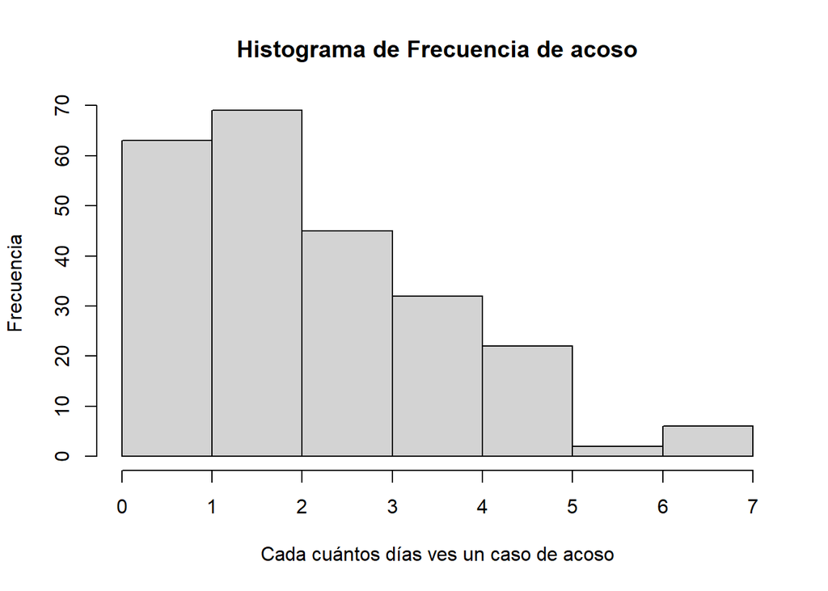

Este tipo de comportamiento puede expresar muchas variables. Sin embargo, por teoría podemos saber que la cantidad de eventos en un intervalo discreto puede modelarse como una distribución Poisson.

Usaremos la librería fitdistrplus para comprobar eso con R.

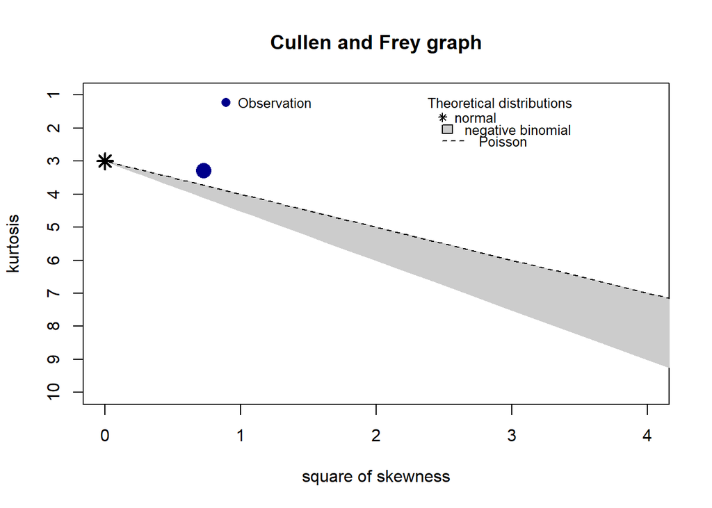

```
## summary statistics
## ------
## min:  0   max:  7
## median:  2
## mean:  2.623431
## estimated sd:  1.486789
## estimated skewness:  0.8523132
## estimated kurtosis:  3.283924
```

```
## Fitting of the distribution ' pois ' by maximum likelihood
## Parameters:
##        estimate Std. Error
## lambda 2.623431  0.1047697
```

Ahora podemos caracterizar la variable y el modelo.

$\text{ Frecuencia de comentarios } \sim Poisson(2.6)$

A partir de esta variable podemos sacar datos y probabilidades teóricas.

La primera pregunta que podríamos hacernos es, si escogemos un Utecino al azar, ¿Cual es la probabilidad de que en una semana presencie mas de 3 casos de acoso virtual o presencial?

```
## [1] 0.2683564
```

La probabilidad de que una persona en una semana presencie mas de 3 casos de acoso en la universidad es de $\% 26.83$

Ahora veremos la probabilidad de que una mujer se sienta más del 80% acosada.

Primero haremos un filtro de solo mujeres a la variable exposición virtual.

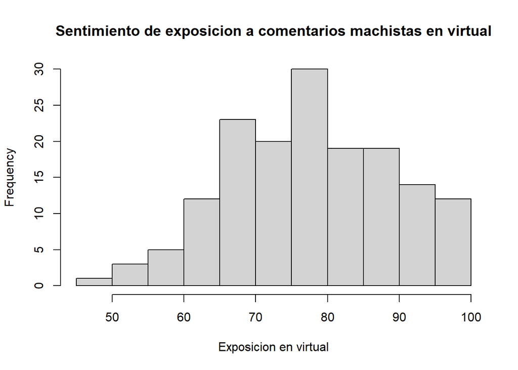

[figure not shown]

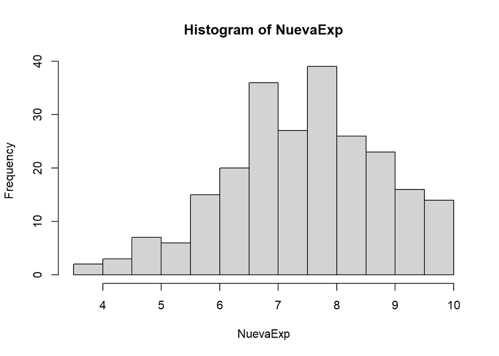

```
## [1] 0.3333333
```

El ultimo modelo que podemos identificar de nuestra base de datos es una Bernulli. Aquí veremos si una persona al azar en la universidad ha sido victima de un caso de acoso. Primero identificamos la probabilidad empírica haciendo un conteo de las personas que han sido victima de acoso entre nuestros encuestados

```
## [1] 0.1004184
```

Luego que tenemos la probabilidad teórica podemos hacernos preguntas en base a la distribución binomial.

La primera pregunta seria, Si de una muestra de 15 encuestados, ¿cual es la probabilidad de que 1 estuvo involucrado en algún caso de acoso?.

```
## [1] 0.3423517
```

Como vemos, la probabilidad de que una persona este acosada entre 15 participantes es de 34% entonces podemos decir que los casos de acoso son altos en la universidad.

El acoso y los comentarios machistas han sido parte del día a día de los Peruanos, pero por este motivo no tenemos que dejar que esto se vuelva algo común.

# 4 **Bibliografía**

Andina. (2022). Sunedu sanciona a dos universidades por no atender correctamente casos de acoso sexual. Recuperado de: (https://andina.pe/agencia/noticia-sunedu-sanciona-a-dos-universidades-no-atender-correctamente-casos-acoso-sexual-890963.aspx)

Barbieri, E., Bacchini, R., Vázquez, L., Bianco, M., Fronti, J. (2018). Introducción a la probabilidad y estadística. Primera edición. Recuperado de: (http://bibliotecadigital.econ.uba.ar/download/libros/Bacchini_Introduccion-a-la-probabilidad-y-a-la-estadistica-2018.pdf)

Lucia Santos P. (2020). Nunca más tendrán la comodidad de nuestro silencio: Análisis de la respuesta institucional de la PUCP ante casos de acoso sexual. Pontificia Universidad Católica del Perú (PUCP). Recuperado de:(https://tesis.pucp.edu.pe/repositorio/bitstream/handle/20.500.12404/16611/SANTOS_PERALTA_LUCIA_MARIEL_NUNCA_COMODIDAD_SILENCIO.pdf?sequence=1&isAllowed=y)

Mendenhall, W., Beaver, J., Beaver, B.(2015). Introducción a la probabilidad y estadística. 4ta edición et al. Recuperado de: (https://issuu.com/cengagelatam/docs/mendenhall_issuu)

Mendenhall, W. (2006). Introducción a la probabilidad y estadística. Décima tercera edición. Recuperado de: (https://www.fcfm.buap.mx/jzacarias/cursos/estad2/libros/book5e2.pdf)